# Lab 1: Introduction to Quarto

Author

Emi Degembe

Published

September 28, 2024

# Part Two: Exploring Quarto Documents

## Specifying Global Execute Options

Execution options specify how the R code in your Quarto document should be displayed. This [guide](https://quarto.org/docs/computations/execution-options.html) provides descriptions on the options you can specify in a document’s execution.

**Question 1** – Add your name and the date to the YAML.

**Question 2** – Add an `execute` line to your YAML that includes the following options, (1) your source code is always output on the page, and (2) your document will render even if there are errors.

## Tooth Growth in Guinea Pigs

```r
# Load a dataset into the R Environment.
data(ToothGrowth)

# Look at the summary of the variables in the dataset.
summary(ToothGrowth)
```

[output not shown]

**Question 3** – Let’s spice this code up a bit. Delete `1 + 1` from the code chunk and paste in the code provided in the Lab 1 instructions.

### Check the Data Documentation

**Question 4** – In your **console** (*not* in the Quarto document), type `?ToothGrowth` (or alternatively `help(ToothGrowth)`.Use the information that pops up in the *Help* pane in RStudio to fill in the blanks below.

*This dataset investigates the effect of* *vitamin C dosage* *on tooth growth in **guinea pigs**.*

*The two supplement delivery methods include OJ **(orange juice)*** *and VC* **(ascorbic acid)**.

*`ToothGrowth` is a data frame with* **60** *observations and* **3** *variables.*

**Question 5** – *Before* the code chunk, change the “Running the Provided Code” section header to a header that better describes the contents of this section (e.g., Tooth Growth Dataset).

## Creating a Plot

**Question 6** – Replace the `plot(pressure)` code with the code provided in the Lab 1 instructions.

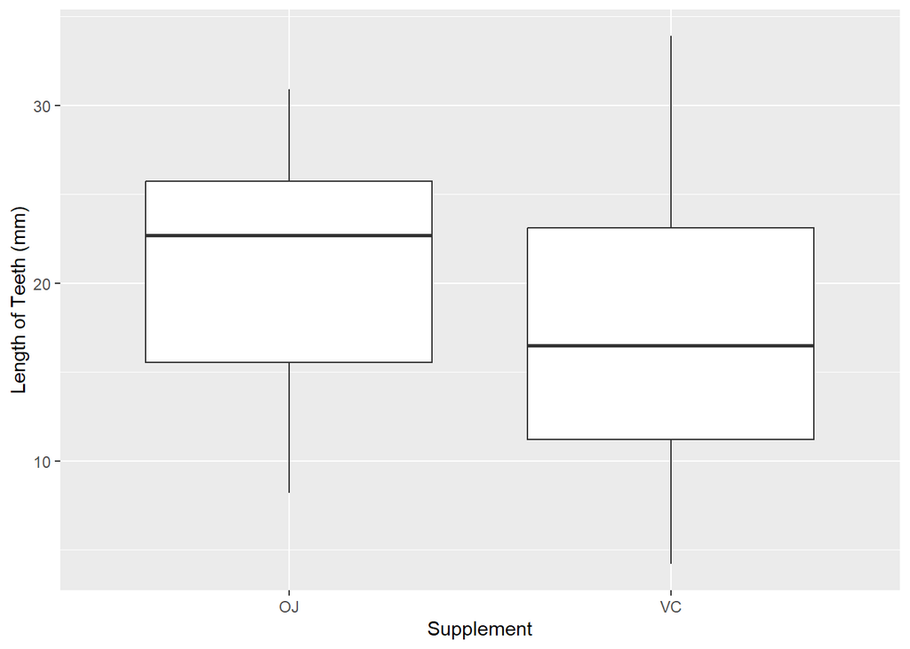

boxplot of tooth growth given supplement method

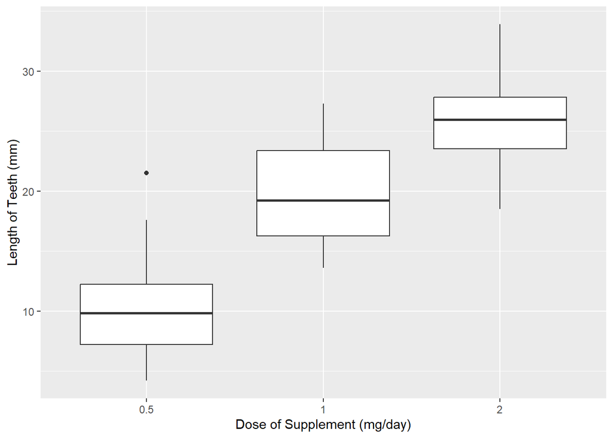

boxplot of tooth growth given supplement dosage

```r
library(tidyverse)

ggplot(data = ToothGrowth,
       mapping = aes(x = supp, y = len)) +
  geom_boxplot() +
  labs(x = "Supplement", y = "Length of Teeth (mm)")
ToothGrowth %>%
  mutate(dose = as.factor(dose)) %>%
  ggplot(mapping = aes(x = dose, y = len)) +
  geom_boxplot() +
  labs(x = "Dose of Supplement (mg/day)", y = "Length of Teeth (mm)")
```

Now, run this code chunk! You should see two side-by-side boxplots, one plot comparing tooth length between the two supplement delivery methods and one plot comparing tooth length between the three different dosages uses.

**Question 7** – Read over the [Quarto documentation on figure options](https://quarto.org/docs/authoring/figures.html#computations) and add an option (`#|`) to the above code chunk to make the figures print side-by-side (i.e., in one row) in the rendered HTML file.

**Question 8** – Specify in the code chunk options that these boxplots should be **center aligned**.

**Question 9** – Specify a **figure caption** for the boxplots (using a code-chunk option).

## Statistical Analysis on `ToothGrowth`

**Question 10** – Using the `t.test()` function, write code to carry out the analysis. You can assume unequal variances and a two-sided alternative.

**Question 11** – Run your code chunk to obtain the output for your statistical test.

```
    Welch Two Sample t-test

data:  len by supp
t = 1.9153, df = 55.309, p-value = 0.06063
alternative hypothesis: true difference in means between group OJ and group VC is not equal to 0
95 percent confidence interval:
 -0.1710156  7.5710156
sample estimates:
mean in group OJ mean in group VC
        20.66333         16.96333
```

**Question 12** – Create a numbered list containing: - your conclusion (in the context of these data) based on the p-value. - an interpretation of the confidence interval (make sure to read what confidence level is used by default).

1. **Conclusion**

   Based on our p-value (.0606), we fail to reject the null hypothesis at the 95% confidence level and conclude we do not have convincing evidence there is a difference in mean tooth length depending on the supplement delivery method.
2. **Interpretation of Confidence Interval**

   At the 95% confidence level, our confidence interval is (-0.1710 , 7.5710). Interpreting this, we are 95% confident that the true difference in mean tooth length depending on supplement delivery method lies between -0.1710mm and 7.5710mm.

**Question 13** – Create another section header, describing the contents of this section.

Challenge is scattered throughout, such as this dark theme!